# Exploring Credit Risk for Lenders and Borrowers

Jessica Gorr

2/5/2025

## 1. Introduction

The purpose of this analysis is to look at some insights and interesting features of credit card risks for both the lender and borrowers. There have been no methods that describe how or where the the data was collected, so we will not take into account on how countries laws are applicable to lenders. The target variable is loan_status, which describes if a borrower has a defaulted loan. The dataset is composed by 32581 rows (observations) and 12 columns (variables), which are described below:

person_age (numerical): is the age of the person at the time of the loan.

person_income (numerical): is the yearly income of the person at the time of the loan.

person_home_ownership (categorical): is the type of ownership of the home.

person_emp_length (numerical): is the amount of time in years that person is employed.

loan_intent (categorical): is the aim of the loan.

loan_grade (categorical): is a classification system that involves assigning a quality score to a loan based on a borrower’s credit history, quality of the collateral, and the likelihood of repayment of the principal and interest.

loan_amnt (numerical): is the dimension of the loan taken.

loan_int_rate (numerical): is the interest paid for the loan.

loan_status (binary): is a dummy variable where 1 is default, 0 is not default.

loan_percent_income (numerical): is the ratio between the loan taken and the annual income.

cb_person_default_on_file (binary): answers whether the person has defaulted before.

cb_person_cred_hist_length (numerical): represents the number of years of personal history since the first loan taken from that person.

A public link to the data can be found here: https://www.kaggle.com/datasets/laotse/credit-risk-dataset

In this assignment, we are looking looking at missing values within the data. Missing values are a common issue in data. These missing values can can be from errors in data entry, or participants skipping survey questions. Missing data can introduce bias, reduce statistical power, and complicate the analysis, making imperative to address these issues before making a model.

There are different types of missing data. One type is Missing Completely at Random (MCAR), where missingness is unrelated to any other data. Another is Missing at Random (MAR), where missingness is related to observed data but not the missing data itself. Finally Missing Not at Random (MNAR), where the missingness depends on unobserved factors, like respondents purposely not responding to certain questions. Understanding the nature of missingness helps in choosing an appropriate imputation method.

There are several imputation techniques to handle missing values. Mean, median, or mode imputation replaces missing values with the average, median, or most frequent value of a column. This is the simplest method and it can distort the data distribution. Regression imputation predicts missing values using other the variables through a regression model. This preserves relationships between variables. K-nearest neighbors (KNN) imputation uses the values of similar observations to fill in the missing data. Multiple imputation generates several plausible datasets by imputing missing values multiple times, reducing bias and uncertainty.

```r
library(dplyr)
library(reshape2)
library(tidyr)
library(ggplot2)
library(tibble)

#Load the sample data
credit_risk_dataset = read.csv("https://jessgorr01.github.io/STA551/sta552/project1/credit_risk_dataset.csv")


head(credit_risk_dataset)
```

```
  person_age person_income person_home_ownership person_emp_length loan_intent
1         22         59000                  RENT               123    PERSONAL
2         21          9600                   OWN                 5   EDUCATION
3         25          9600              MORTGAGE                 1     MEDICAL
4         23         65500                  RENT                 4     MEDICAL
5         24         54400                  RENT                 8     MEDICAL
6         21          9900                   OWN                 2     VENTURE
  loan_grade loan_amnt loan_int_rate loan_status loan_percent_income
1          D     35000         16.02           1                0.59
2          B      1000         11.14           0                0.10
3          C      5500         12.87           1                0.57
4          C     35000         15.23           1                0.53
5          C     35000         14.27           1                0.55
6          A      2500          7.14           1                0.25
  cb_person_default_on_file cb_person_cred_hist_length
1                         Y                          3
2                         N                          2
3                         N                          3
4                         N                          2
5                         Y                          4
6                         N                          2
```

## 2. Distribution of Individual Features

### Cleaning and first looks

```r
#Transforming variables to factors
credit_risk_dataset$loan_status <- as.factor(credit_risk_dataset$loan_status)
credit_risk_dataset$person_home_ownership <- as.factor(credit_risk_dataset$person_home_ownership)
credit_risk_dataset$loan_intent <- as.factor(credit_risk_dataset$loan_intent)
credit_risk_dataset$loan_grade <- as.factor(credit_risk_dataset$loan_grade)
credit_risk_dataset$cb_person_default_on_file <- as.factor(credit_risk_dataset$cb_person_default_on_file)

glimpse(credit_risk_dataset) # more ordered
```

```
Rows: 32,581
Columns: 12
$ person_age                 <int> 22, 21, 25, 23, 24, 21, 26, 24, 24, 21, 22,…
$ person_income              <int> 59000, 9600, 9600, 65500, 54400, 9900, 7710…
$ person_home_ownership      <fct> RENT, OWN, MORTGAGE, RENT, RENT, OWN, RENT,…
$ person_emp_length          <dbl> 123, 5, 1, 4, 8, 2, 8, 5, 8, 6, 6, 2, 2, 4,…
$ loan_intent                <fct> PERSONAL, EDUCATION, MEDICAL, MEDICAL, MEDI…
$ loan_grade                 <fct> D, B, C, C, C, A, B, B, A, D, B, A, A, E, A…
$ loan_amnt                  <int> 35000, 1000, 5500, 35000, 35000, 2500, 3500…
$ loan_int_rate              <dbl> 16.02, 11.14, 12.87, 15.23, 14.27, 7.14, 12…
$ loan_status                <fct> 1, 0, 1, 1, 1, 1, 1, 1, 1, 1, 1, 1, 1, 1, 0…
$ loan_percent_income        <dbl> 0.59, 0.10, 0.57, 0.53, 0.55, 0.25, 0.45, 0…
$ cb_person_default_on_file  <fct> Y, N, N, N, Y, N, N, N, N, N, N, N, N, N, N…
$ cb_person_cred_hist_length <int> 3, 2, 3, 2, 4, 2, 3, 4, 2, 3, 4, 2, 2, 4, 4…
```

```r
#str(credit_risk_dataset)
```

The summary of our data, including missing values is below:

```r
summary(credit_risk_dataset)
```

```
   person_age     person_income     person_home_ownership person_emp_length
 Min.   : 20.00   Min.   :   4000   MORTGAGE:13444        Min.   :  0.00
 1st Qu.: 23.00   1st Qu.:  38500   OTHER   :  107        1st Qu.:  2.00
 Median : 26.00   Median :  55000   OWN     : 2584        Median :  4.00
 Mean   : 27.73   Mean   :  66075   RENT    :16446        Mean   :  4.79
 3rd Qu.: 30.00   3rd Qu.:  79200                         3rd Qu.:  7.00
 Max.   :144.00   Max.   :6000000                         Max.   :123.00
                                                          NA's   :895
            loan_intent   loan_grade   loan_amnt     loan_int_rate
 DEBTCONSOLIDATION:5212   A:10777    Min.   :  500   Min.   : 5.42
 EDUCATION        :6453   B:10451    1st Qu.: 5000   1st Qu.: 7.90
 HOMEIMPROVEMENT  :3605   C: 6458    Median : 8000   Median :10.99
 MEDICAL          :6071   D: 3626    Mean   : 9589   Mean   :11.01
 PERSONAL         :5521   E:  964    3rd Qu.:12200   3rd Qu.:13.47
 VENTURE          :5719   F:  241    Max.   :35000   Max.   :23.22
                          G:   64                    NA's   :3116
 loan_status loan_percent_income cb_person_default_on_file
 0:25473     Min.   :0.0000      N:26836
 1: 7108     1st Qu.:0.0900      Y: 5745
             Median :0.1500
             Mean   :0.1702
             3rd Qu.:0.2300
             Max.   :0.8300

 cb_person_cred_hist_length
 Min.   : 2.000
 1st Qu.: 3.000
 Median : 4.000
 Mean   : 5.804
 3rd Qu.: 8.000
 Max.   :30.000
```

```r
colSums(is.na(credit_risk_dataset))  # Number of NAs in each column
```

```
                person_age              person_income
                         0                          0
     person_home_ownership          person_emp_length
                         0                        895
               loan_intent                 loan_grade
                         0                          0
                 loan_amnt              loan_int_rate
                         0                       3116
               loan_status        loan_percent_income
                         0                          0
 cb_person_default_on_file cb_person_cred_hist_length
                         0                          0
```

A quick look at the data we can see that:

1.person_emp_length has 895 NAs 2.loan_int_rate has 3116 NAS

### Mode Imputation

Mode Imputation is a technique used to handle missing values in categorical variables by replacing them with the most frequently occurring value (mode) in that column. This method ensures that missing values are filled with a plausible category rather than dropping data points, preserving the dataset’s original structure.

Now that the dataset is clean, we can start to impute some of the missing values. The fist task is to replace NA categorical values with the mode. This can be seen below:

```r
# Function to replace NA with mode
replace_na_with_mode <- function(x) {
  mode_value <- names(sort(table(x), decreasing = TRUE))[1]  # Find mode
  x[is.na(x)] <- mode_value  # Replace NA with mode
  return(x)
}

# Apply function to categorical columns in the credit_risk_dataset
credit_risk_mode <- credit_risk_dataset %>%
  mutate(across(where(is.factor), replace_na_with_mode))

# Check if missing values are replaced
glimpse(credit_risk_mode)
```

```
Rows: 32,581
Columns: 12
$ person_age                 <int> 22, 21, 25, 23, 24, 21, 26, 24, 24, 21, 22,…
$ person_income              <int> 59000, 9600, 9600, 65500, 54400, 9900, 7710…
$ person_home_ownership      <fct> RENT, OWN, MORTGAGE, RENT, RENT, OWN, RENT,…
$ person_emp_length          <dbl> 123, 5, 1, 4, 8, 2, 8, 5, 8, 6, 6, 2, 2, 4,…
$ loan_intent                <fct> PERSONAL, EDUCATION, MEDICAL, MEDICAL, MEDI…
$ loan_grade                 <fct> D, B, C, C, C, A, B, B, A, D, B, A, A, E, A…
$ loan_amnt                  <int> 35000, 1000, 5500, 35000, 35000, 2500, 3500…
$ loan_int_rate              <dbl> 16.02, 11.14, 12.87, 15.23, 14.27, 7.14, 12…
$ loan_status                <fct> 1, 0, 1, 1, 1, 1, 1, 1, 1, 1, 1, 1, 1, 1, 0…
$ loan_percent_income        <dbl> 0.59, 0.10, 0.57, 0.53, 0.55, 0.25, 0.45, 0…
$ cb_person_default_on_file  <fct> Y, N, N, N, Y, N, N, N, N, N, N, N, N, N, N…
$ cb_person_cred_hist_length <int> 3, 2, 3, 2, 4, 2, 3, 4, 2, 3, 4, 2, 2, 4, 4…
```

```r
colSums(is.na(credit_risk_mode))  # Number of NAs in each column
```

```
                person_age              person_income
                         0                          0
     person_home_ownership          person_emp_length
                         0                        895
               loan_intent                 loan_grade
                         0                          0
                 loan_amnt              loan_int_rate
                         0                       3116
               loan_status        loan_percent_income
                         0                          0
 cb_person_default_on_file cb_person_cred_hist_length
                         0                          0
```

Looking at the dataset, we can see that there are no categorical missing values. Some implications of mode imputation is that it ensures data completeness, but it could introduce bias and reduce variability. For small missingness, it’s a simple and convenient solution, but for larger missing data or complex datasets, more advanced imputation methods like regression based and multiple imputation method should be used.

## 3. Regression Based Impuation Methods for Numerical Features

Regression-based imputation is a method where missing numerical variable values are predicted using a regression model trained on complete cases. This ensures that missing values are filled in a way that maintains relationships between variables. If the varibles do not have complete cases, some missing values will be left.

Below is the code for creating two regression models, for person_emp_length and loan_interest rate.

```r
credit_risk_regression <- credit_risk_dataset

# Build a linear regression model using complete cases
emp_model <- lm(person_emp_length ~ person_age + person_income + loan_amnt + loan_int_rate,
                data = credit_risk_regression, na.action = na.omit)

# Predict missing values
missing_emp_rows <- is.na(credit_risk_regression$person_emp_length)
credit_risk_regression$person_emp_length[missing_emp_rows] <- predict(emp_model,
    newdata = credit_risk_regression[missing_emp_rows,])


# Build a regression model using complete cases
int_rate_model <- lm(loan_int_rate ~ person_age + person_income + loan_amnt + loan_percent_income,
                     data = credit_risk_regression, na.action = na.omit)

# Predict missing values
missing_int_rate_rows <- is.na(credit_risk_regression$loan_int_rate)
credit_risk_regression$loan_int_rate[missing_int_rate_rows] <- predict(int_rate_model,
    newdata = credit_risk_regression[missing_int_rate_rows,])

colSums(is.na(credit_risk_dataset))
```

```
                person_age              person_income
                         0                          0
     person_home_ownership          person_emp_length
                         0                        895
               loan_intent                 loan_grade
                         0                          0
                 loan_amnt              loan_int_rate
                         0                       3116
               loan_status        loan_percent_income
                         0                          0
 cb_person_default_on_file cb_person_cred_hist_length
                         0                          0
```

```r
colSums(is.na(credit_risk_regression))  # Check if missing values are replaced
```

```
                person_age              person_income
                         0                          0
     person_home_ownership          person_emp_length
                         0                         68
               loan_intent                 loan_grade
                         0                          0
                 loan_amnt              loan_int_rate
                         0                          0
               loan_status        loan_percent_income
                         0                          0
 cb_person_default_on_file cb_person_cred_hist_length
                         0                          0
```

From our output, we can see that all missing values for loan_interest_rate were imputed, but not all for person_emp_length. There are 68 remaining. This could be due to not having enough information, and outliers.

## 4. Multible Imputation

Multiple Regression-based imputation is a method where missing numerical values are predicted using regression models based on other available features. This imputation method helps maintain relationships between variables and provides more accurate imputations compared to mode imputation for categorical variables and median/mean for numerical variables.

Below we will use the mice() library to do a regression based imputation. There are two variable with multiple missing values, person_emp_length, which is how long someone is employed, and loan_int_rate, which is the interest rate of the loan.

```r
# Load necessary package
library(mice)

# Select only numerical columns for regression imputation
num_vars <- c("person_emp_length", "loan_int_rate")

# Perform regression-based imputation
imputed_data <- mice(credit_risk_dataset, method = "norm.predict", m = 1)
# Get the completed dataset with imputed values
credit_risk_dataset_imputed <- complete(imputed_data)

# Check if missing values are removed
colSums(is.na(credit_risk_dataset_imputed))
```

```
                person_age              person_income
                         0                          0
     person_home_ownership          person_emp_length
                         0                          0
               loan_intent                 loan_grade
                         0                          0
                 loan_amnt              loan_int_rate
                         0                          0
               loan_status        loan_percent_income
                         0                          0
 cb_person_default_on_file cb_person_cred_hist_length
                         0                          0
```

```r
summary(credit_risk_dataset)
```

```
   person_age     person_income     person_home_ownership person_emp_length
 Min.   : 20.00   Min.   :   4000   MORTGAGE:13444        Min.   :  0.00
 1st Qu.: 23.00   1st Qu.:  38500   OTHER   :  107        1st Qu.:  2.00
 Median : 26.00   Median :  55000   OWN     : 2584        Median :  4.00
 Mean   : 27.73   Mean   :  66075   RENT    :16446        Mean   :  4.79
 3rd Qu.: 30.00   3rd Qu.:  79200                         3rd Qu.:  7.00
 Max.   :144.00   Max.   :6000000                         Max.   :123.00
                                                          NA's   :895
            loan_intent   loan_grade   loan_amnt     loan_int_rate
 DEBTCONSOLIDATION:5212   A:10777    Min.   :  500   Min.   : 5.42
 EDUCATION        :6453   B:10451    1st Qu.: 5000   1st Qu.: 7.90
 HOMEIMPROVEMENT  :3605   C: 6458    Median : 8000   Median :10.99
 MEDICAL          :6071   D: 3626    Mean   : 9589   Mean   :11.01
 PERSONAL         :5521   E:  964    3rd Qu.:12200   3rd Qu.:13.47
 VENTURE          :5719   F:  241    Max.   :35000   Max.   :23.22
                          G:   64                    NA's   :3116
 loan_status loan_percent_income cb_person_default_on_file
 0:25473     Min.   :0.0000      N:26836
 1: 7108     1st Qu.:0.0900      Y: 5745
             Median :0.1500
             Mean   :0.1702
             3rd Qu.:0.2300
             Max.   :0.8300

 cb_person_cred_hist_length
 Min.   : 2.000
 1st Qu.: 3.000
 Median : 4.000
 Mean   : 5.804
 3rd Qu.: 8.000
 Max.   :30.000
```

```r
summary(credit_risk_dataset_imputed)
```

```
   person_age     person_income     person_home_ownership person_emp_length
 Min.   : 20.00   Min.   :   4000   MORTGAGE:13444        Min.   :  0.000
 1st Qu.: 23.00   1st Qu.:  38500   OTHER   :  107        1st Qu.:  2.000
 Median : 26.00   Median :  55000   OWN     : 2584        Median :  4.000
 Mean   : 27.73   Mean   :  66075   RENT    :16446        Mean   :  4.784
 3rd Qu.: 30.00   3rd Qu.:  79200                         3rd Qu.:  7.000
 Max.   :144.00   Max.   :6000000                         Max.   :123.000

            loan_intent   loan_grade   loan_amnt     loan_int_rate
 DEBTCONSOLIDATION:5212   A:10777    Min.   :  500   Min.   : 5.42
 EDUCATION        :6453   B:10451    1st Qu.: 5000   1st Qu.: 7.88
 HOMEIMPROVEMENT  :3605   C: 6458    Median : 8000   Median :10.99
 MEDICAL          :6071   D: 3626    Mean   : 9589   Mean   :11.01
 PERSONAL         :5521   E:  964    3rd Qu.:12200   3rd Qu.:13.47
 VENTURE          :5719   F:  241    Max.   :35000   Max.   :23.22
                          G:   64
 loan_status loan_percent_income cb_person_default_on_file
 0:25473     Min.   :0.0000      N:26836
 1: 7108     1st Qu.:0.0900      Y: 5745
             Median :0.1500
             Mean   :0.1702
             3rd Qu.:0.2300
             Max.   :0.8300

 cb_person_cred_hist_length
 Min.   : 2.000
 1st Qu.: 3.000
 Median : 4.000
 Mean   : 5.804
 3rd Qu.: 8.000
 Max.   :30.000
```

## 5. Feature Transforming

### Data Cleaning

From the first assignment we have identified many illogical outliers such as outrageous ages and working experience. Below we will filter out these outliers again using our imputed data

```r
credit_risk <- credit_risk_dataset_imputed %>%
    filter(!is.na(person_emp_length)) %>%
    filter(!is.na(loan_int_rate)) %>%
    filter(person_age < 90) %>%
    filter(person_emp_length < 100)

summary(credit_risk)
```

```
   person_age    person_income     person_home_ownership person_emp_length
 Min.   :20.00   Min.   :   4000   MORTGAGE:13441        Min.   : 0.000
 1st Qu.:23.00   1st Qu.:  38500   OTHER   :  107        1st Qu.: 2.000
 Median :26.00   Median :  55000   OWN     : 2584        Median : 4.000
 Mean   :27.72   Mean   :  65880   RENT    :16441        Mean   : 4.776
 3rd Qu.:30.00   3rd Qu.:  79200                         3rd Qu.: 7.000
 Max.   :84.00   Max.   :2039784                         Max.   :41.000

            loan_intent   loan_grade   loan_amnt     loan_int_rate
 DEBTCONSOLIDATION:5212   A:10776    Min.   :  500   Min.   : 5.42
 EDUCATION        :6451   B:10448    1st Qu.: 5000   1st Qu.: 7.88
 HOMEIMPROVEMENT  :3605   C: 6455    Median : 8000   Median :10.99
 MEDICAL          :6070   D: 3625    Mean   : 9588   Mean   :11.01
 PERSONAL         :5519   E:  964    3rd Qu.:12200   3rd Qu.:13.47
 VENTURE          :5716   F:  241    Max.   :35000   Max.   :23.22
                          G:   64
 loan_status loan_percent_income cb_person_default_on_file
 0:25466     Min.   :0.0000      N:26829
 1: 7107     1st Qu.:0.0900      Y: 5744
             Median :0.1500
             Mean   :0.1702
             3rd Qu.:0.2300
             Max.   :0.8300

 cb_person_cred_hist_length
 Min.   : 2.000
 1st Qu.: 3.000
 Median : 4.000
 Mean   : 5.803
 3rd Qu.: 8.000
 Max.   :30.000
```

```r
# Log Transformation (for positively skewed variables)
credit_risk <- credit_risk %>%
  mutate(person_income_log = log1p(person_income),  # log1p(x) = log(x + 1) to handle zeros
         loan_amnt_log = log1p(loan_amnt))

# Square Root Transformation (moderate skewness)
credit_risk <- credit_risk %>%
  mutate(person_age_sqrt = sqrt(person_age),
         person_emp_length_sqrt = sqrt(person_emp_length),
         cb_person_cred_hist_length_sqrt = sqrt(cb_person_cred_hist_length))

# Inverse Transformation (for extreme right skew)
credit_risk <- credit_risk %>%
  mutate(loan_int_rate_inv = 1 / (loan_int_rate + 1),  # Avoid division by zero
         loan_percent_income_inv = 1 / (loan_percent_income + 1))
```

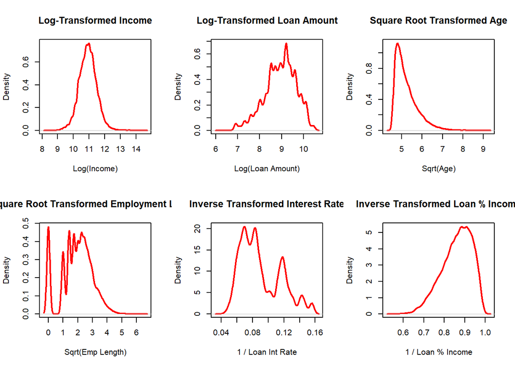

```r
par(mfrow = c(2, 3))  # Arrange plots in a grid


plot(density(credit_risk$person_income_log, na.rm = TRUE),
     main = "Log-Transformed Income", xlab = "Log(Income)", col = "red", lwd = 2)

plot(density(credit_risk$loan_amnt_log, na.rm = TRUE),
     main = "Log-Transformed Loan Amount", xlab = "Log(Loan Amount)", col = "red", lwd = 2)

plot(density(credit_risk$person_age_sqrt, na.rm = TRUE),
     main = "Square Root Transformed Age", xlab = "Sqrt(Age)", col = "red", lwd = 2)

plot(density(credit_risk$person_emp_length_sqrt, na.rm = TRUE),
     main = "Square Root Transformed Employment Length", xlab = "Sqrt(Emp Length)", col = "red", lwd = 2)

plot(density(credit_risk$loan_int_rate_inv, na.rm = TRUE),
     main = "Inverse Transformed Interest Rate", xlab = "1 / Loan Int Rate", col = "red", lwd = 2)

plot(density(credit_risk$loan_percent_income_inv, na.rm = TRUE),
     main = "Inverse Transformed Loan % Income", xlab = "1 / Loan % Income", col = "red", lwd = 2)
```

## 5. Feature Selection

When looking some of the relationships between varibles, we can use logistical modeling to see the reslationships and filter down to only the significant features. We will start with the full model with our target feature loan_status. From there, we will use step-wise regression to keep only significant terms. Our tranfromed features will be used.

Below is the code for the full logistical model

```r
# Fit the full logistic regression model with all predictors
full_logit_model <- glm(loan_status ~ person_age_sqrt + person_income_log + person_home_ownership +
                        person_emp_length_sqrt + loan_intent + loan_grade + loan_amnt_log + loan_int_rate +
                        loan_percent_income_inv + cb_person_default_on_file + cb_person_cred_hist_length_sqrt,
                        data = credit_risk,
                        family = binomial())

# Check summary of the full logistic regression model
summary(full_logit_model)
```

```
Call:
glm(formula = loan_status ~ person_age_sqrt + person_income_log +
    person_home_ownership + person_emp_length_sqrt + loan_intent +
    loan_grade + loan_amnt_log + loan_int_rate + loan_percent_income_inv +
    cb_person_default_on_file + cb_person_cred_hist_length_sqrt,
    family = binomial(), data = credit_risk)

Deviance Residuals:
    Min       1Q   Median       3Q      Max
-3.0830  -0.5196  -0.2891  -0.1128   3.5753

Coefficients:
                                  Estimate Std. Error z value Pr(>|z|)
(Intercept)                      29.834606   0.700758  42.575  < 2e-16 ***
person_age_sqrt                  -0.002624   0.063012  -0.042  0.96679
person_income_log                 0.582413   0.087944   6.623 3.53e-11 ***
person_home_ownershipOTHER        0.474789   0.287099   1.654  0.09818 .
person_home_ownershipOWN         -1.767249   0.099648 -17.735  < 2e-16 ***
person_home_ownershipRENT         0.760042   0.040628  18.707  < 2e-16 ***
person_emp_length_sqrt           -0.060672   0.017704  -3.427  0.00061 ***
loan_intentEDUCATION             -0.854646   0.057381 -14.894  < 2e-16 ***
loan_intentHOMEIMPROVEMENT        0.090504   0.064299   1.408  0.15926
loan_intentMEDICAL               -0.165196   0.054188  -3.049  0.00230 **
loan_intentPERSONAL              -0.621924   0.058703 -10.594  < 2e-16 ***
loan_intentVENTURE               -1.111492   0.062258 -17.853  < 2e-16 ***
loan_gradeB                       0.115488   0.080292   1.438  0.15033
loan_gradeC                       0.292048   0.122491   2.384  0.01711 *
loan_gradeD                       2.397429   0.154698  15.497  < 2e-16 ***
loan_gradeE                       2.621084   0.194726  13.460  < 2e-16 ***
loan_gradeF                       2.913332   0.266553  10.930  < 2e-16 ***
loan_gradeG                       6.679045   1.063937   6.278 3.44e-10 ***
loan_amnt_log                    -1.815676   0.083386 -21.774  < 2e-16 ***
loan_int_rate                     0.075872   0.017936   4.230 2.33e-05 ***
loan_percent_income_inv         -26.493013   0.766288 -34.573  < 2e-16 ***
cb_person_default_on_fileY       -0.009210   0.050463  -0.183  0.85518
cb_person_cred_hist_length_sqrt  -0.023155   0.045194  -0.512  0.60840
---
Signif. codes:  0 '***' 0.001 '**' 0.01 '*' 0.05 '.' 0.1 ' ' 1

(Dispersion parameter for binomial family taken to be 1)

    Null deviance: 34176  on 32572  degrees of freedom
Residual deviance: 21694  on 32550  degrees of freedom
AIC: 21740

Number of Fisher Scoring iterations: 6
```

Now lets use stepwise regression.

```r
# Perform stepwise logistic regression (both directions)
stepwise_logit_model <- step(full_logit_model, direction = "both", trace = 1)
```

```
Start:  AIC=21739.63
loan_status ~ person_age_sqrt + person_income_log + person_home_ownership +
    person_emp_length_sqrt + loan_intent + loan_grade + loan_amnt_log +
    loan_int_rate + loan_percent_income_inv + cb_person_default_on_file +
    cb_person_cred_hist_length_sqrt

                                  Df Deviance   AIC
- person_age_sqrt                  1    21694 21738
- cb_person_default_on_file        1    21694 21738
- cb_person_cred_hist_length_sqrt  1    21694 21738
<none>                                  21694 21740
- person_emp_length_sqrt           1    21705 21749
- loan_int_rate                    1    21712 21756
- person_income_log                1    21735 21779
- loan_amnt_log                    1    22095 22139
- loan_intent                      5    22306 22342
- loan_percent_income_inv          1    22752 22796
- person_home_ownership            3    22905 22945
- loan_grade                       6    23201 23235

Step:  AIC=21737.64
loan_status ~ person_income_log + person_home_ownership + person_emp_length_sqrt +
    loan_intent + loan_grade + loan_amnt_log + loan_int_rate +
    loan_percent_income_inv + cb_person_default_on_file + cb_person_cred_hist_length_sqrt

                                  Df Deviance   AIC
- cb_person_default_on_file        1    21694 21736
- cb_person_cred_hist_length_sqrt  1    21695 21737
<none>                                  21694 21738
+ person_age_sqrt                  1    21694 21740
- person_emp_length_sqrt           1    21705 21747
- loan_int_rate                    1    21712 21754
- person_income_log                1    21735 21777
- loan_amnt_log                    1    22095 22137
- loan_intent                      5    22308 22342
- loan_percent_income_inv          1    22752 22794
- person_home_ownership            3    22905 22943
- loan_grade                       6    23202 23234

Step:  AIC=21735.67
```

[output cut: 21 more lines]

```
    loan_percent_income_inv

                                  Df Deviance   AIC
<none>                                  21695 21735
+ cb_person_cred_hist_length_sqrt  1    21694 21736
+ person_age_sqrt                  1    21694 21736
+ cb_person_default_on_file        1    21695 21737
- person_emp_length_sqrt           1    21707 21745
- loan_int_rate                    1    21713 21751
- person_income_log                1    21736 21774
- loan_amnt_log                    1    22095 22133
- loan_intent                      5    22308 22338
- loan_percent_income_inv          1    22753 22791
- person_home_ownership            3    22907 22941
- loan_grade                       6    23205 23233
```

```r
# View the final model summary
summary(stepwise_logit_model)
```

```
Call:
glm(formula = loan_status ~ person_income_log + person_home_ownership +
    person_emp_length_sqrt + loan_intent + loan_grade + loan_amnt_log +
    loan_int_rate + loan_percent_income_inv, family = binomial(),
    data = credit_risk)

Deviance Residuals:
    Min       1Q   Median       3Q      Max
-3.0831  -0.5191  -0.2891  -0.1130   3.5727

Coefficients:
                            Estimate Std. Error z value Pr(>|z|)
(Intercept)                 29.78964    0.66288  44.940  < 2e-16 ***
person_income_log            0.57905    0.08783   6.593 4.31e-11 ***
person_home_ownershipOTHER   0.47706    0.28670   1.664 0.096125 .
person_home_ownershipOWN    -1.76876    0.09964 -17.751  < 2e-16 ***
person_home_ownershipRENT    0.75959    0.04062  18.698  < 2e-16 ***
person_emp_length_sqrt      -0.06181    0.01765  -3.502 0.000462 ***
loan_intentEDUCATION        -0.85203    0.05730 -14.870  < 2e-16 ***
loan_intentHOMEIMPROVEMENT   0.08703    0.06417   1.356 0.175038
loan_intentMEDICAL          -0.16667    0.05417  -3.077 0.002091 **
loan_intentPERSONAL         -0.62309    0.05869 -10.617  < 2e-16 ***
loan_intentVENTURE          -1.11128    0.06225 -17.852  < 2e-16 ***
loan_gradeB                  0.11590    0.08027   1.444 0.148793
loan_gradeC                  0.28794    0.11991   2.401 0.016335 *
loan_gradeD                  2.39345    0.15251  15.694  < 2e-16 ***
loan_gradeE                  2.61758    0.19312  13.554  < 2e-16 ***
loan_gradeF                  2.90954    0.26560  10.955  < 2e-16 ***
loan_gradeG                  6.66726    1.06321   6.271 3.59e-10 ***
loan_amnt_log               -1.81449    0.08336 -21.768  < 2e-16 ***
loan_int_rate                0.07570    0.01793   4.222 2.42e-05 ***
loan_percent_income_inv    -26.48261    0.76603 -34.571  < 2e-16 ***
---
Signif. codes:  0 '***' 0.001 '**' 0.01 '*' 0.05 '.' 0.1 ' ' 1

(Dispersion parameter for binomial family taken to be 1)

    Null deviance: 34176  on 32572  degrees of freedom
Residual deviance: 21695  on 32553  degrees of freedom
AIC: 21735

Number of Fisher Scoring iterations: 6
```

When comparing the two models, the reduced model has a lower AIC score, which is better.

Now that we have significant terms, we must also think about domain knowledge. When thinking of loan defaults what variables may have an impact? I think the variables that must be kept are age, income, income_percentage, and interest_rate.

Now we will filter out and only keep those variables.

```r
# Create a new dataset with only the selected variables
filtered_dataset <- credit_risk[, c("person_age_sqrt", "person_income_log", "loan_percent_income_inv", "loan_int_rate", "loan_status")]

# Check the first few rows of the new dataset
head(filtered_dataset)
```

```
  person_age_sqrt person_income_log loan_percent_income_inv loan_int_rate
1        4.582576          9.169623               0.9090909         11.14
2        5.000000          9.169623               0.6369427         12.87
3        4.795832         11.089821               0.6535948         15.23
4        4.898979         10.904138               0.6451613         14.27
5        4.582576          9.200391               0.8000000          7.14
6        5.099020         11.252872               0.6896552         12.42
  loan_status
1           0
2           1
3           1
4           1
5           1
6           1
```

## 5. Feature Creation

From the previous assignment we have identified categorical variables that should be regrouped to simplify our model. Regrouping simplies our model, which imporves our power.

These can be shown being regrouped below:

```r
# 1. Regrouping Credit History (cb_person_cred_hist_length) into categories
filtered_dataset <- credit_risk %>%
  mutate(credit_history_group = case_when(
    cb_person_cred_hist_length <= 5 ~ "0-5 years",
    cb_person_cred_hist_length <= 10 ~ "5-10 years",
    cb_person_cred_hist_length > 10 ~ "11+ years"
  ))

# 2. Regrouping Loan Grade (loan_grade) into groups
filtered_dataset_ <- credit_risk %>%
  mutate(loan_grade_group = case_when(
    loan_grade %in% c("A", "B") ~ "A-B",
    loan_grade %in% c("C", "D") ~ "C-D",
    loan_grade %in% c("E", "F", "G") ~ "E-G"
  ))

# 3. Regrouping Loan Intent (loan_intent) into Necessity vs Want
filtered_dataset_ <- credit_risk%>%
  mutate(loan_intent_group = case_when(
    loan_intent == "MEDICAL" ~ "Necessity",
    loan_intent %in% c("PERSONAL", "VENTURE") ~ "Want",
    loan_intent == "EDUCATION" ~ "Other"  # If you want to handle other categories
  ))

# Check the results
head(filtered_dataset)
```

```
  person_age person_income person_home_ownership person_emp_length loan_intent
1         21          9600                   OWN                 5   EDUCATION
2         25          9600              MORTGAGE                 1     MEDICAL
3         23         65500                  RENT                 4     MEDICAL
4         24         54400                  RENT                 8     MEDICAL
5         21          9900                   OWN                 2     VENTURE
6         26         77100                  RENT                 8   EDUCATION
  loan_grade loan_amnt loan_int_rate loan_status loan_percent_income
1          B      1000         11.14           0                0.10
2          C      5500         12.87           1                0.57
3          C     35000         15.23           1                0.53
4          C     35000         14.27           1                0.55
5          A      2500          7.14           1                0.25
6          B     35000         12.42           1                0.45
  cb_person_default_on_file cb_person_cred_hist_length person_income_log
```

[output cut: 27 more lines]

Now let’s move in decrectizing some of our numerical variables. This is useful for multiple reasons, including improving model interpretability, handling non-linearity, and reducing noisy data. This os grouping continous data. Some of the variables we are going to discretize are age, income and interest rates.

Below is the code in order to discretize data

```r
credit_risk <- credit_risk %>%
  # Discretize Age
  mutate(person_age= case_when(
    person_age <= 30 ~ "Young",
    person_age > 30 & person_age <= 50 ~ "Middle-Aged",
    person_age > 50 ~ "Older",
    TRUE ~ NA_character_  # Handle unexpected values
  )) %>%

  # Discretize Income
  mutate(person_income = case_when(
    person_income < 25000 ~ "Low Income",
    person_income >= 25000 & person_income <= 75000 ~ "Middle Income",
    person_income > 75000 ~ "High Income",
    TRUE ~ NA_character_
  )) %>%

  # Discretize Loan Interest Rate
  mutate(loan_int_rate = case_when(
    loan_int_rate < 10 ~ "Low Interest",
    loan_int_rate >= 10 & loan_int_rate <= 20 ~ "Medium Interest",
    loan_int_rate > 20 ~ "High Interest",
    TRUE ~ NA_character_
  )) %>%

  # Discretize Loan Percentage of Income
  mutate(loan_percent_income = case_when(
    loan_percent_income < 0.2 ~ "Low Burden",
    loan_percent_income >= 0.2 & loan_percent_income <= 0.5 ~ "Medium Burden",
    loan_percent_income > 0.5 ~ "High Burden",
    TRUE ~ NA_character_
  ))

# Convert new columns to factors

# Check the first few rows
head(credit_risk)
```

```
  person_age person_income person_home_ownership person_emp_length loan_intent
1      Young    Low Income                   OWN                 5   EDUCATION
2      Young    Low Income              MORTGAGE                 1     MEDICAL
3      Young Middle Income                  RENT                 4     MEDICAL
4      Young Middle Income                  RENT                 8     MEDICAL
5      Young    Low Income                   OWN                 2     VENTURE
6      Young   High Income                  RENT                 8   EDUCATION
  loan_grade loan_amnt   loan_int_rate loan_status loan_percent_income
1          B      1000 Medium Interest           0          Low Burden
2          C      5500 Medium Interest           1         High Burden
3          C     35000 Medium Interest           1         High Burden
4          C     35000 Medium Interest           1         High Burden
5          A      2500    Low Interest           1       Medium Burden
6          B     35000 Medium Interest           1       Medium Burden
  cb_person_default_on_file cb_person_cred_hist_length person_income_log
```

[output cut: 20 more lines]

## Conclusion

This analysis we identified missing observations and imputed values using mode, regression and multiple imputation techniques. Then we used feature engineering to select and manipulate features for appropriate analysis.